# SI 370 - Homework #4: Machine Learning 1

In this homework exercise you will apply the machine learning techniques we've covered so far: linear regression, machine learning pipelines, agglomerative clustering, k-means clustering, and t-SNE.

We will be using [graduate admissions data](https://www.kaggle.com/mohansacharya/graduate-admissions).

This is a fairly involved homework assignment and we *strongly* urge you to not leave this to the last minute. We suggest that you try to work on this assignment over several days.

```python
import numpy as np
import pandas as pd
import seaborn as sns
import matplotlib.pyplot as plt
```

```python
admit = pd.read_csv('https://raw.githubusercontent.com/umsi-data-science/data/main/Admission_Predict.csv',
                    index_col="Serial No.")
```

```python
admit.shape
```

```
(500, 8)
```

```python
admit.head()
```

|  | GRE Score | TOEFL Score | University Rating | SOP | LOR | CGPA | Research | Chance of Admit |
| --- | --- | --- | --- | --- | --- | --- | --- | --- |
| 0 | 337 | 118 | 4 | 4.5 | 4.5 | 9.65 | 1 | 0.92 |
| 1 | 324 | 107 | 4 | 4.0 | 4.5 | 8.87 | 1 | 0.76 |
| 2 | 316 | 104 | 3 | 3.0 | 3.5 | 8.00 | 1 | 0.72 |
| 3 | 322 | 110 | 3 | 3.5 | 2.5 | 8.67 | 1 | 0.80 |
| 4 | 314 | 103 | 2 | 2.0 | 3.0 | 8.21 | 0 | 0.65 |

## Task 1 (2 points):

Perform basic exploratory data analyses on the variables in this dataframe. Your work should include both numerical **and** graphical overviews of the data. The `multiplePlots` code might be helpful here.

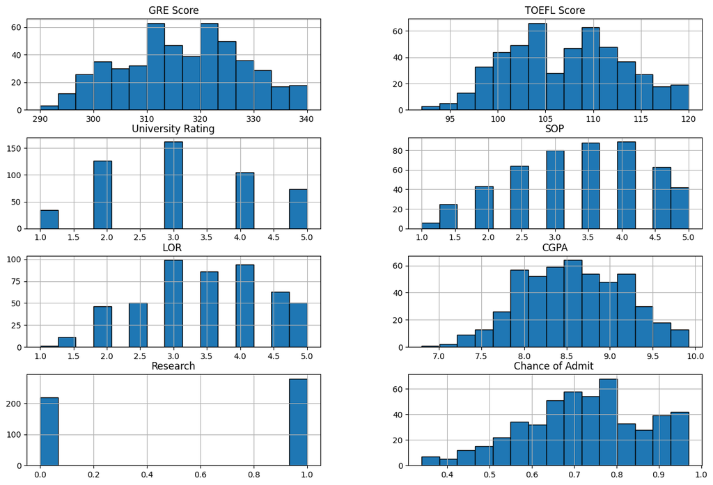

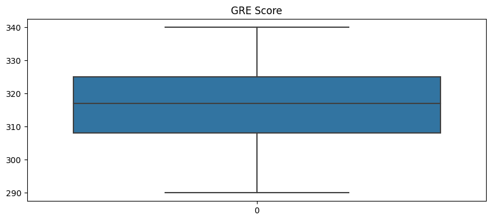

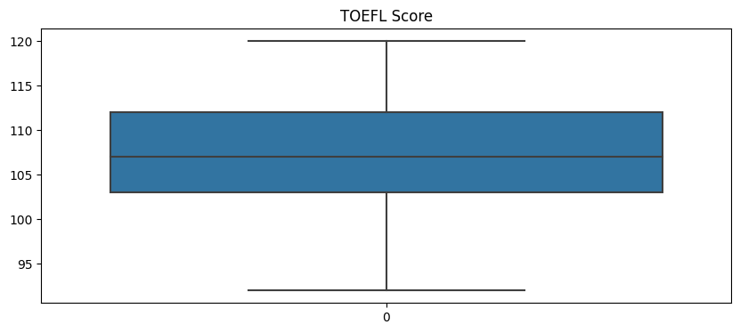

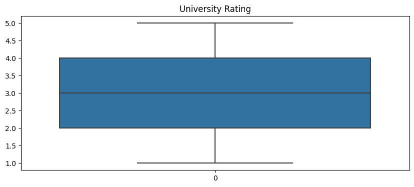

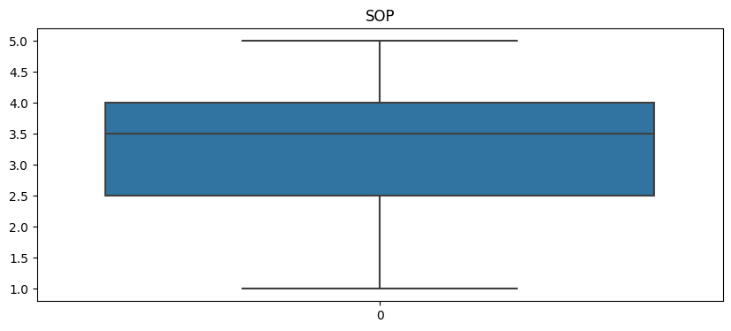

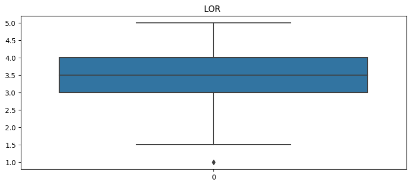

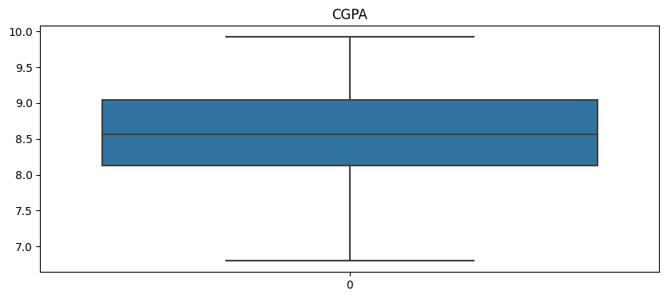

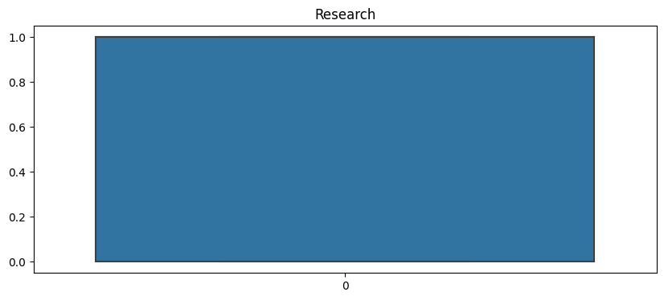

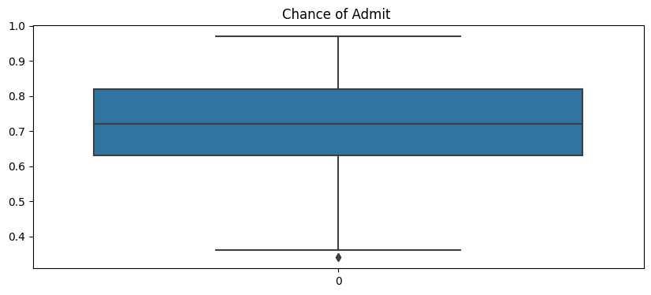

```
/Users/jason/Desktop/SI 370 Master/si370fa23-student-main 2/.venv/lib/python3.11/site-packages/seaborn/axisgrid.py:118: UserWarning: The figure layout has changed to tight
  self._figure.tight_layout(*args, **kwargs)
```

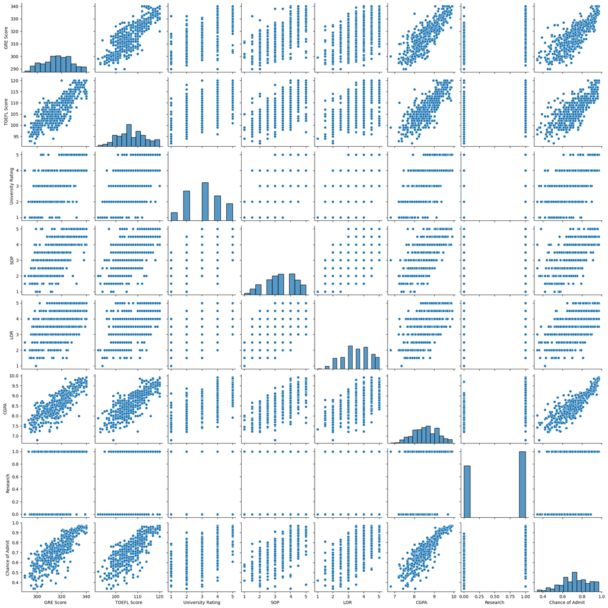

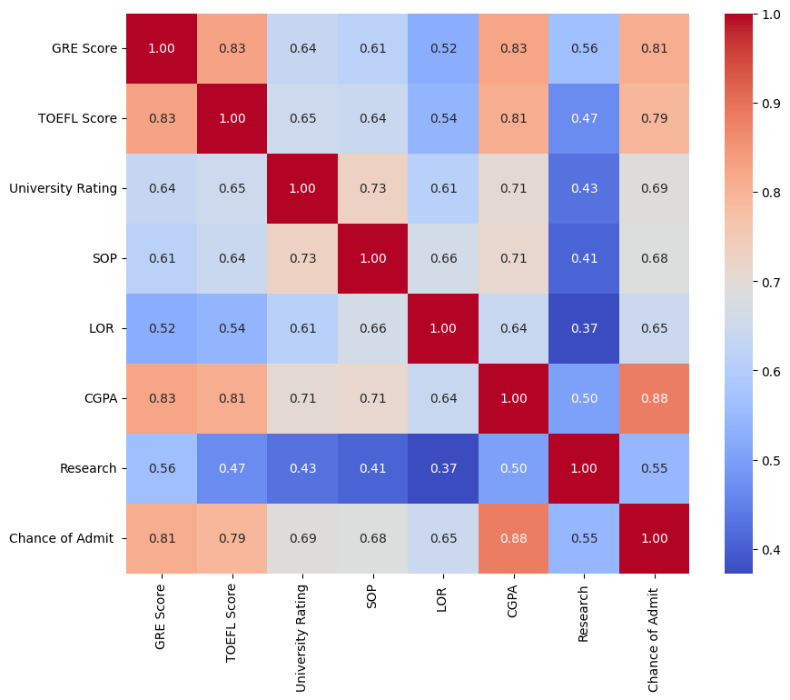

```python
admit.hist(bins=15, figsize=(15, 10), layout=(4, 2), edgecolor='black');

# Box plots to visualize distributions and identify any potential outliers
for column in admit.columns:
    plt.figure(figsize=(10, 4))
    sns.boxplot(admit[column])
    plt.title(column)
    plt.show()

# Scatter plots to visualize the relationships between variables
sns.pairplot(admit)
plt.show()

# Heatmap of the correlation matrix to understand the relationships between variables
plt.figure(figsize=(10, 8))
sns.heatmap(admit.corr(), annot=True, fmt='.2f', cmap='coolwarm')
plt.show()
```

```python
print(f"Dataset contains {admit.shape[0]} rows and {admit.shape[1]} columns.")

print(admit.head())

print(admit.describe())

print(admit.isnull().sum())

print(f"Number of duplicate rows: {admit.duplicated().sum()}")

print(admit.dtypes)
```

```
Dataset contains 500 rows and 8 columns.
   GRE Score  TOEFL Score  University Rating  SOP  LOR   CGPA  Research  \
0        337          118                  4  4.5   4.5  9.65         1
1        324          107                  4  4.0   4.5  8.87         1
2        316          104                  3  3.0   3.5  8.00         1
3        322          110                  3  3.5   2.5  8.67         1
4        314          103                  2  2.0   3.0  8.21         0

   Chance of Admit
0              0.92
1              0.76
2              0.72
3              0.80
4              0.65
        GRE Score  TOEFL Score  University Rating         SOP       LOR   \
count  500.000000   500.000000         500.000000  500.000000  500.00000
mean   316.472000   107.192000           3.114000    3.374000    3.48400
std     11.295148     6.081868           1.143512    0.991004    0.92545
min    290.000000    92.000000           1.000000    1.000000    1.00000
25%    308.000000   103.000000           2.000000    2.500000    3.00000
50%    317.000000   107.000000           3.000000    3.500000    3.50000
75%    325.000000   112.000000           4.000000    4.000000    4.00000
max    340.000000   120.000000           5.000000    5.000000    5.00000

             CGPA    Research  Chance of Admit
count  500.000000  500.000000         500.00000
mean     8.576440    0.560000           0.72174
std      0.604813    0.496884           0.14114
min      6.800000    0.000000           0.34000
25%      8.127500    0.000000           0.63000
50%      8.560000    1.000000           0.72000
75%      9.040000    1.000000           0.82000
max      9.920000    1.000000           0.97000
GRE Score            0
TOEFL Score          0
University Rating    0
SOP                  0
LOR                  0
CGPA                 0
Research             0
Chance of Admit      0
dtype: int64
Number of duplicate rows: 0
GRE Score              int64
TOEFL Score            int64
University Rating      int64
SOP                  float64
LOR                  float64
CGPA                 float64
Research               int64
Chance of Admit      float64
dtype: object
```

## Task 2a (4 points):

Use scikit-learn to conduct a linear regression that models the chance of admission based on the other variables. Be sure to exclude "Serial No." as an explanatory variable. Be sure to pre-process the data appropriately. Assess how good your model is by reporting the root mean squared error (RMSE) using the test dataset from an 80-20 train-test-split of the original dataset.

```python
from sklearn.model_selection import train_test_split
from sklearn.linear_model import LinearRegression
from sklearn.preprocessing import StandardScaler
from sklearn.metrics import mean_squared_error, r2_score
```

```python
target_column = 'Chance of Admit '

X = admit.drop(target_column, axis=1)
y = admit[target_column]

X_train, X_test, y_train, y_test = train_test_split(X, y, test_size=0.2, random_state=42)

scaler = StandardScaler()
X_train_scaled = scaler.fit_transform(X_train)
X_test_scaled = scaler.transform(X_test)

model = LinearRegression()
model.fit(X_train_scaled, y_train)

y_pred = model.predict(X_test_scaled)

mse = mean_squared_error(y_test, y_pred)
r2 = r2_score(y_test, y_pred)

print('Coefficients:', model.coef_)
print('Intercept:', model.intercept_)
print('Mean squared error (MSE):', mse)
print('Coefficient of determination (R^2):', r2)
```

```
Coefficients: [0.02667052 0.01822633 0.00293995 0.001788   0.0158655  0.06758106
 0.01194049]
Intercept: 0.7241749999999999
Mean squared error (MSE): 0.0037046553987884127
Coefficient of determination (R^2): 0.8188432567829628
```

## Task 2b (1 point):

Based on your work in the previous task, what is the probability of admission for someone with a GRE score or 325, a TOEFL score of 108, a university rating of 3, an statement of purpose score of 3.0, a letter of recommendation score of 3.5, a high-school grade point average of 8.9, and who has research experience.

```python
new_data = np.array([[325, 108, 3, 3.0, 3.5, 8.9, 1]])

new_data_scaled = scaler.transform(new_data)

predicted_probability = model.predict(new_data_scaled)

predicted_admission_probability = predicted_probability[0]

print(f"The predicted probability of admission is: {predicted_admission_probability:.2f}")
```

```
The predicted probability of admission is: 0.79
```

```
/Users/jason/Desktop/SI 370 Master/si370fa23-student-main 2/.venv/lib/python3.11/site-packages/sklearn/base.py:464: UserWarning: X does not have valid feature names, but StandardScaler was fitted with feature names
  warnings.warn(
```

As we can see from above, the predicted probability of admission is 79%.

## Task 3 (1 points):

Decide on a reasonable value for a threshold for admission. Pick a value that you would feel comfortable with if you wanted to know whether you were likely to be accepted into a graduate program. Create a new variable called "admitted" that is set to 1 if the chance of admission value is equal to or greater than your chosen threshold, 0 otherwise.

```python
threshold = 0.75

admit['admitted'] = (admit['Chance of Admit '] >= threshold).astype(int)
print(admit[['Chance of Admit ', 'admitted']].head())
```

```
   Chance of Admit   admitted
0              0.92         1
1              0.76         1
2              0.72         0
3              0.80         1
4              0.65         0
```

We can see above, if an individual has a .75 chance or higher or being admitted, then they are admitted. Initially I thought .50 would be a good rate in which students should be admitted, but I felt like .75 was a more realistic value for a school like UCLA.

## Task 4 (5 points):

Using your **test** dataset (i.e. approximately 80 rows) from above, conduct an agglomerative clustering analysis using average linkage based on PCA projections of the original data onto 2 dimensions (remember to scale your data before doing the PCA). Report the percentage of variance retained in the first two principal components.

Do not use the chance of admission column or the "admitted" variable you created in the previous step in your input data.

Create a dendrogram, pick an appropriate "cut line" and comment on the composition of each of the resulting clusters. Comment on the degree to which the clusters correspond to admission probabilities (note: you may find it helpful to examine the values of "admitted").

```
Percentage of variance retained in the first two principal components: 79.60%
```

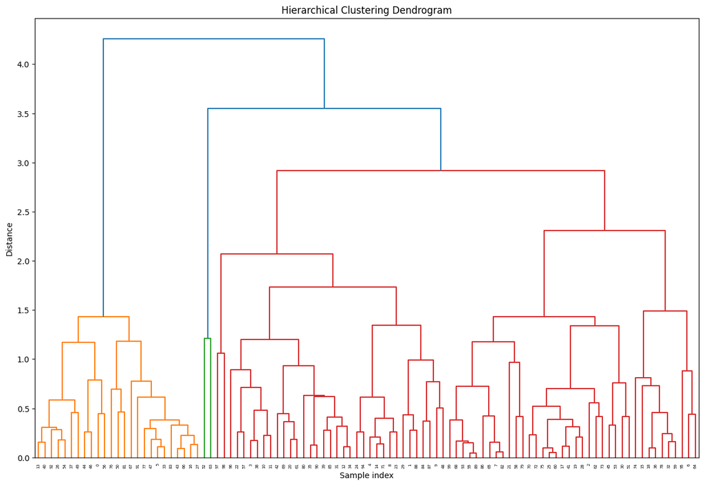

```python
from sklearn.decomposition import PCA
from sklearn.cluster import AgglomerativeClustering
from scipy.cluster.hierarchy import dendrogram, linkage
import matplotlib.pyplot as plt

pca = PCA(n_components=2)
X_test_pca = pca.fit_transform(X_test_scaled)

variance_retained = pca.explained_variance_ratio_.sum() * 100
print(f"Percentage of variance retained in the first two principal components: {variance_retained:.2f}%")

linkage_matrix = linkage(X_test_pca, method='average')

plt.figure(figsize=(15, 10))
dendrogram(linkage_matrix)
plt.title('Hierarchical Clustering Dendrogram')
plt.xlabel('Sample index')
plt.ylabel('Distance')
plt.show()
```

The result indicating that 79.60% of the variance is retained in the first two principal components means that these two components capture a significant portion of the information in the dataset. This level of variance retention indicates that the two-dimensional PCA projection preserves much of the structure of the data, making it suitable for clustering.

## Task 5 (4 points):

Conduct a k-means clustering of the admissions data. Pre-process the data using a 2-dimensional PCA (remember to scale your data before doing the PCA). Again, do not use the chance of admission or the "admitted" variable you created earlier. Use the average silhouette score to determine the optimal number of clusters and show the silhouette plot for the optimal number of clusters.

[output not shown]

```
For n_clusters = 2, the average silhouette_score is : 0.5147557577452744
For n_clusters = 3, the average silhouette_score is : 0.43105985799311386
For n_clusters = 4, the average silhouette_score is : 0.40581234449210485
For n_clusters = 5, the average silhouette_score is : 0.41612946114318533
For n_clusters = 6, the average silhouette_score is : 0.3759766250144698
For n_clusters = 7, the average silhouette_score is : 0.3624914877102601
For n_clusters = 8, the average silhouette_score is : 0.387242311968569
For n_clusters = 9, the average silhouette_score is : 0.3713787068952245
The optimal number of clusters is: 2
```

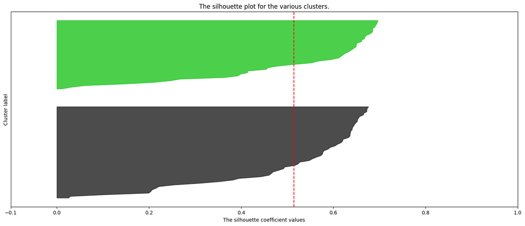

```python
from sklearn.decomposition import PCA
from sklearn.cluster import KMeans
from sklearn.metrics import silhouette_score, silhouette_samples
import matplotlib.cm as cm


pca = PCA(n_components=2)
X_test_pca = pca.fit_transform(X_test_scaled)

range_n_clusters = list(range(2, 10))
silhouette_avg_scores = []

for num_clusters in range_n_clusters:
    clusterer = KMeans(n_clusters=num_clusters, random_state=10)
    cluster_labels = clusterer.fit_predict(X_test_pca)
    silhouette_avg = silhouette_score(X_test_pca, cluster_labels)
    silhouette_avg_scores.append(silhouette_avg)
    print(f"For n_clusters = {num_clusters}, the average silhouette_score is : {silhouette_avg}")

optimal_num_clusters = range_n_clusters[silhouette_avg_scores.index(max(silhouette_avg_scores))]
print(f"The optimal number of clusters is: {optimal_num_clusters}")

optimal_clusterer = KMeans(n_clusters=optimal_num_clusters, random_state=10)
optimal_cluster_labels = optimal_clusterer.fit_predict(X_test_pca)

fig, ax1 = plt.subplots(1, 1)
fig.set_size_inches(18, 7)

silhouette_vals = silhouette_samples(X_test_pca, optimal_cluster_labels)

y_lower = 10
for i in range(optimal_num_clusters):
    ith_cluster_silhouette_values = silhouette_vals[optimal_cluster_labels == i]
    ith_cluster_silhouette_values.sort()
    size_cluster_i = ith_cluster_silhouette_values.shape[0]
    y_upper = y_lower + size_cluster_i
    color = cm.nipy_spectral(float(i) / optimal_num_clusters)
    ax1.fill_betweenx(np.arange(y_lower, y_upper), 0, ith_cluster_silhouette_values, facecolor=color, edgecolor=color, alpha=0.7)
    y_lower = y_upper + 10  # 10 for the 0 samples gap

ax1.set_title("The silhouette plot for the various clusters.")
ax1.set_xlabel("The silhouette coefficient values")
ax1.set_ylabel("Cluster label")

ax1.axvline(x=silhouette_avg_scores[optimal_num_clusters-2], color="red", linestyle="--")

ax1.set_yticks([])  # Clear the yaxis labels / ticks
ax1.set_xticks([-0.1, 0, 0.2, 0.4, 0.6, 0.8, 1])

plt.show()
```

## Task 6 (3 points):

Show the results of a t-SNE analysis of the admissions data. As before, do not use the chance of admission column or the "admitted" variable you created in the previous step in your input data. Color the points in your visualization based on the "admitted" variable you created earlier.

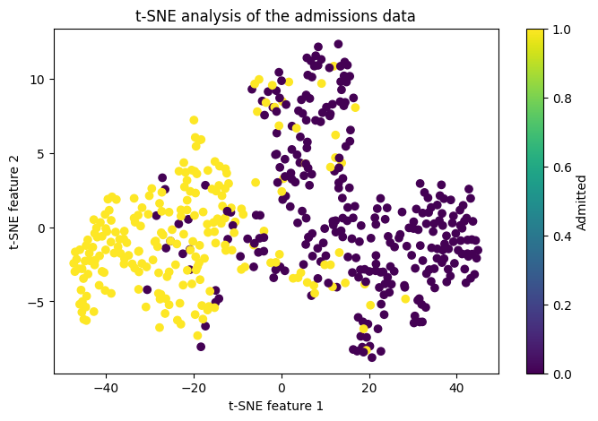

```python
threshold = 0.75
admit['admitted'] = (admit['Chance of Admit '] >= threshold).astype(int)

tsne_data = admit.drop(columns=['Chance of Admit ', 'admitted'])

tsne = TSNE(n_components=2, random_state=42)
tsne_results = tsne.fit_transform(tsne_data)

plt.figure(figsize=(8, 5))
scatter = plt.scatter(tsne_results[:, 0], tsne_results[:, 1], c=admit['admitted'], cmap='viridis')
plt.title('t-SNE analysis of the admissions data')
plt.xlabel('t-SNE feature 1')
plt.ylabel('t-SNE feature 2')
plt.colorbar(scatter, label='Admitted')
plt.show()
```

The chart above shows the t-SNE analysis of the admission data. We can see the clustering between the two groups: being admitted (yellow) and not being admitted (purple).